Campaign Contributions From Ohio For Election 2012 by Christian Villere ========================================================

```
## 'data.frame':    150207 obs. of  18 variables:
##  $ cmte_id          : Factor w/ 15 levels "C00410118","C00431171",..: 7 7 7 3 3 3 3 3 3 7 ...
##  $ cand_id          : Factor w/ 14 levels "P00003608","P20002523",..: 12 12 12 13 13 13 13 13 13 12 ...
##  $ cand_nm          : Factor w/ 14 levels "Bachmann, Michele",..: 8 8 8 7 7 7 7 7 7 8 ...
##  $ contbr_nm        : Factor w/ 35416 levels "`SCHMIDT, MICHELLE",..: 3903 7760 16781 16546 22411 950 16899 3646 16359 19447 ...
##  $ contbr_city      : Factor w/ 1167 levels ":POLAND","`LOVELAND",..: 55 159 747 95 243 286 212 198 1094 339 ...
##  $ contbr_st        : Factor w/ 1 level "OH": 1 1 1 1 1 1 1 1 1 1 ...
##  $ contbr_zip       : Factor w/ 23138 levels "","00000","00005",..: 16357 14388 14467 3004 3354 20777 9438 17840 22308 8187 ...
##  $ contbr_employer  : Factor w/ 13507 levels "","(SELF) GREEN LEAF LAWN CARE",..: 4663 8163 3331 7980 10056 6281 9833 9833 9162 3888 ...
##  $ contbr_occupation: Factor w/ 6846 levels "","-","100% DISABLED VIETNAM VETERAN",..: 2053 5237 1266 2851 3503 6209 4733 5237 6113 5488 ...
##  $ contb_receipt_amt: num  50 25 201 100 50 ...
##  $ contb_receipt_dt : Factor w/ 633 levels "01-APR-11","01-APR-12",..: 110 110 110 619 537 558 619 537 65 110 ...
##  $ receipt_desc     : Factor w/ 16 levels "","REATTRIBUTED",..: 1 1 1 1 1 1 1 1 1 1 ...
##  $ memo_cd          : Factor w/ 2 levels "","X": 1 1 1 1 1 1 1 1 1 1 ...
##  $ memo_text        : Factor w/ 80 levels "","*","* EARMARKED CONTRIBUTION: SEE BELOW",..: 1 1 1 1 1 1 1 1 1 1 ...
##  $ form_tp          : Factor w/ 3 levels "SA17A","SA18",..: 1 1 1 1 1 1 1 1 1 1 ...
##  $ file_num         : int  779227 779227 779227 756218 756218 756218 756218 756218 756218 779227 ...
##  $ tran_id          : Factor w/ 129180 levels "0000018","0000074",..: 2948 2949 2950 7871 7552 7571 7874 7555 6776 2921 ...
##  $ election_tp      : Factor w/ 7 levels "","G2008","G2012",..: 7 7 7 7 7 7 7 7 7 7 ...
```

# Univariate Plots Section

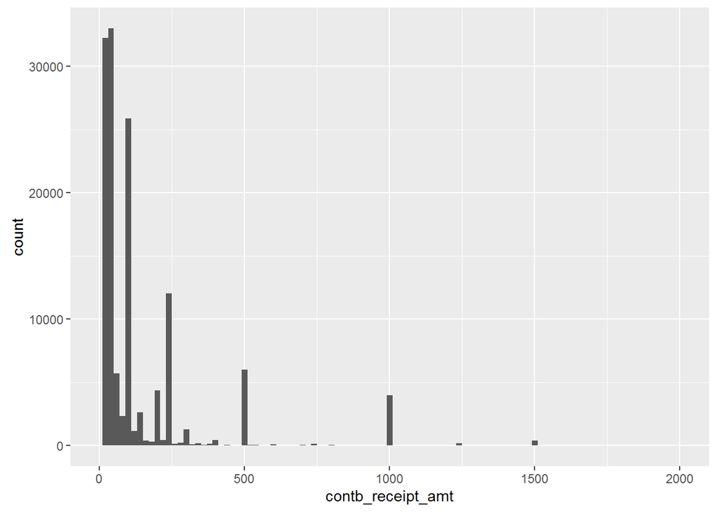

Data is heavily skewed toward lower contribution amounts. Lets take a log of the x scale to see if we can determine which of the contribution amounts was most popular.

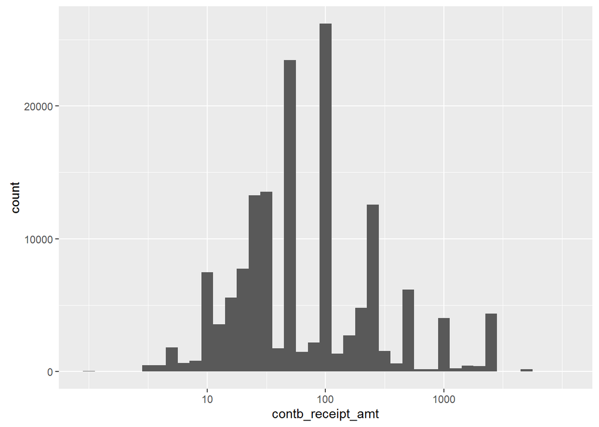

The most common contribution amount is $100. That makes a lot of sense since its a common amount in general and on an online contribution form it is most likely a box that folks can check to determine that’s how much they want to give. Due to this variable looking so approximately normal, I’m going to use the scale transformation throughout the report.

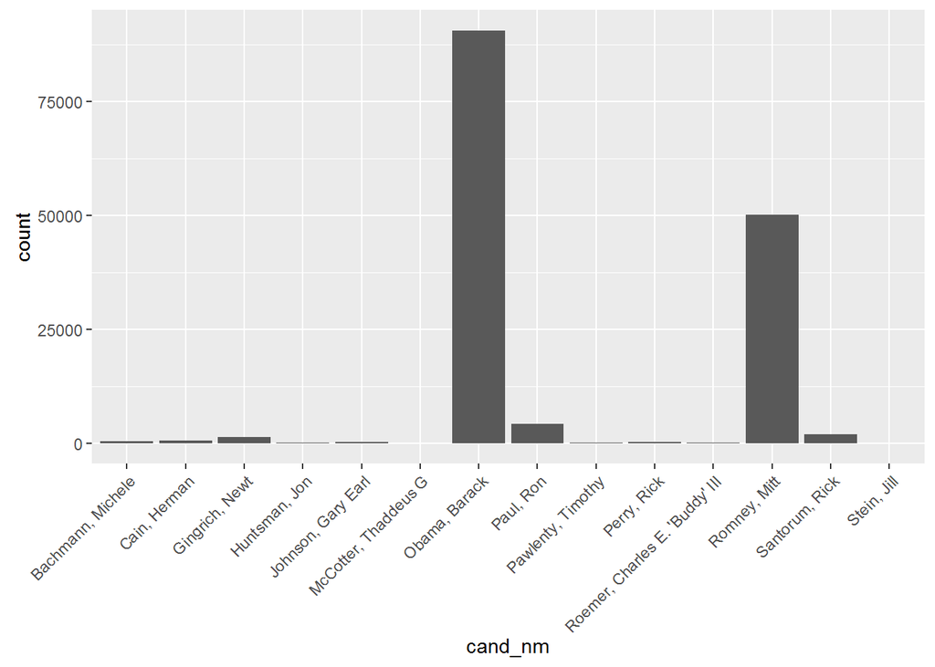

Although there were 14 candidates in the race, only two, Mitt Romney and Barack Obama received a significant number of donations. The instructions suggest to add the gender of each candidate or the political party, but at this time neither additional variable appears interesting or enlightening.

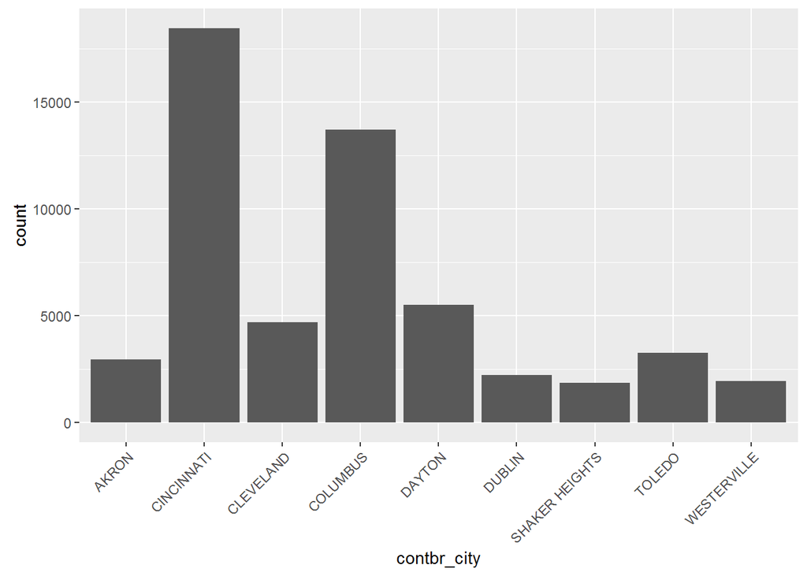

```
##        CINCINNATI          COLUMBUS            DAYTON         CLEVELAND
##             18446             13703              5488              4697
##            TOLEDO             AKRON            DUBLIN       WESTERVILLE
##              3261              2940              2201              1931
##    SHAKER HEIGHTS            CANTON     CHAGRIN FALLS            POWELL
##              1849              1524              1508              1353
##      WEST CHESTER CLEVELAND HEIGHTS          LAKEWOOD          WESTLAKE
##              1338              1285              1236              1231
##       WORTHINGTON          LOVELAND            HUDSON            ATHENS
##              1172              1124              1101              1098
```

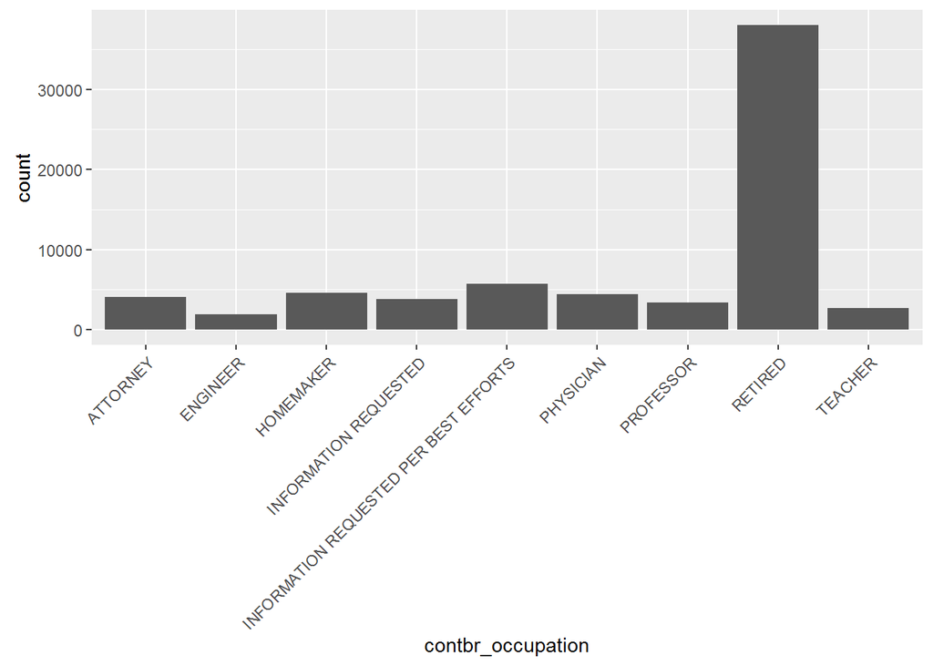

```
##                                RETIRED
##                                  38029
## INFORMATION REQUESTED PER BEST EFFORTS
##                                   5759
##                              HOMEMAKER
##                                   4623
##                              PHYSICIAN
##                                   4447
##                               ATTORNEY
##                                   4033
##                  INFORMATION REQUESTED
##                                   3818
##                              PROFESSOR
##                                   3378
##                                TEACHER
##                                   2683
##                               ENGINEER
##                                   1908
##                                MANAGER
##                                   1577
##                                  SALES
##                                   1562
##                                   NONE
##                                   1435
##                           NOT EMPLOYED
##                                   1320
##                              PRESIDENT
##                                   1317
##                             CONSULTANT
##                                   1310
##                          SELF-EMPLOYED
##                                   1049
##                                  OWNER
##                                    980
##                                     RN
##                                    799
##                         BUSINESS OWNER
##                                    791
##                                STUDENT
##                                    764
```

Here’s where things get interesting from my point of view. The occupation of the folks who gave most frequently is listed as retired. Let’s delve into that a little bit. It is pretty amazing they represent such a large number of the political contributions in the state. Judging from the summary of the professions, it appears this is a list of only individuals.If the list did include businesses, it would make the representation of retired folks on this list even larger. Unfortunately, two of the professions listed, “information requested per best effors” and “information requested” do not provide us with any information about the profession of almost 10,000 contributors or dataset observations.

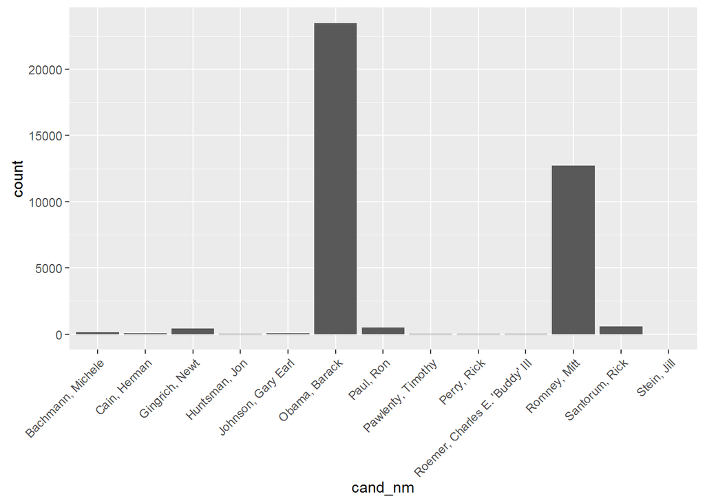

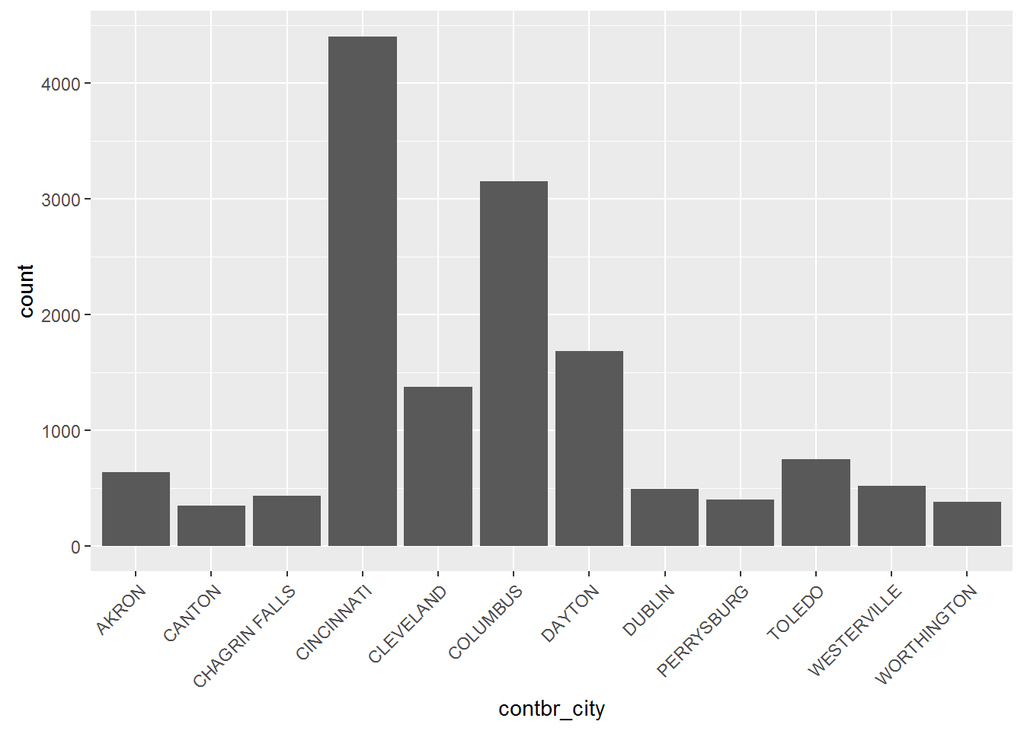

The top 3 cities for where political contributions came from is the same for retired people as it is for the entire sample of contributors.

# Univariate Analysis

### What is/are the main feature(s) of interest in your dataset?

The main features of interest in the dataset are the contribution amount, and the candidate awarded with that contribution.

### What other features in the dataset do you think will help support your investigation into your feature(s) of interest?

Other features of interest are what the contributors do for a living and where they actually live.

### Did you create any new variables from existing variables in the dataset?

I didn’t create any new variables because I can’t determine there is any benefit to doing so at this stage. The assignment suggests adding a variable for candidate gender or candiate political party. Right now, I don’t see any analytical benefit to adding either of those two variables or any other variable.

### Of the features you investigated, were there any unusual distributions? Did you perform any operations on the data to tidy, adjust, or change the form of the data? If so, why did you do this?

There were a couple things I had to do early on that were unique to this dataset. First, it was not assimple as using the read.csv command to read in the data. According to another user, whom I credit in my resources section, the 2012 data has a trailing comma. Due to this, R thinks there is an extra column. I used some code from the user to create the additional column, read in the data, and manage to do so without causing any issues with the column names being moved one to the right, which was a problem with other solutions. Second, it appears there were some contribution amounts of zero. I subsetted them from the data, due to them not being necessary, and may look at them later on depending where the analysis takes me.

# Bivariate Plots Section

Let’s take a look at contribution amount and contributor city together.

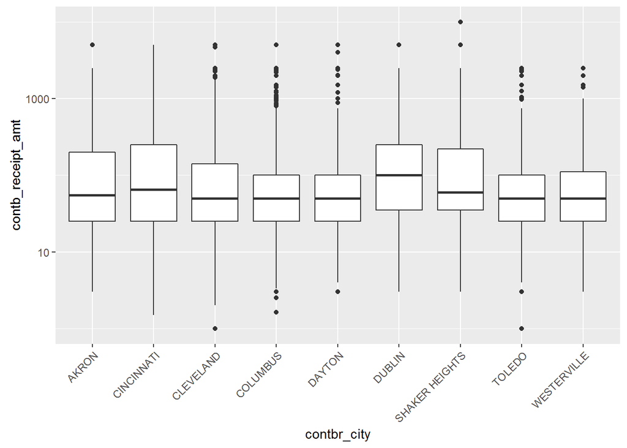

Let’s consider contribution amount and occupation

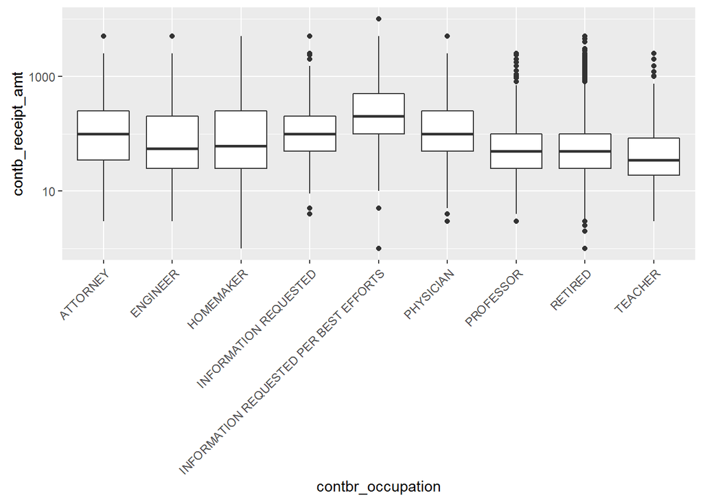

Let’s consider contribution amount and being retired.

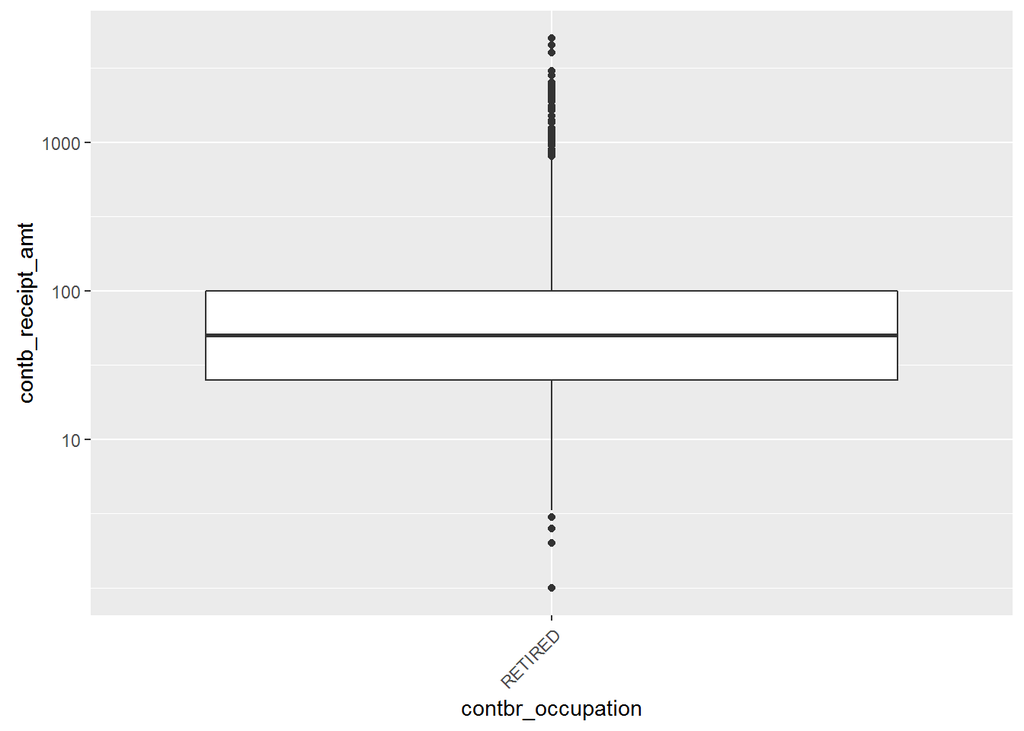

```
##    Min. 1st Qu.  Median    Mean 3rd Qu.    Max.
##     1.0    25.0    50.0   154.5   100.0  5000.0
```

Fairly plain graph. Median line sits right at $50. Top of the box at $100, and lower end of the box at $25. Lots of outliers beyond the $1000 mark.

Let’s take a look at contribution amount and date

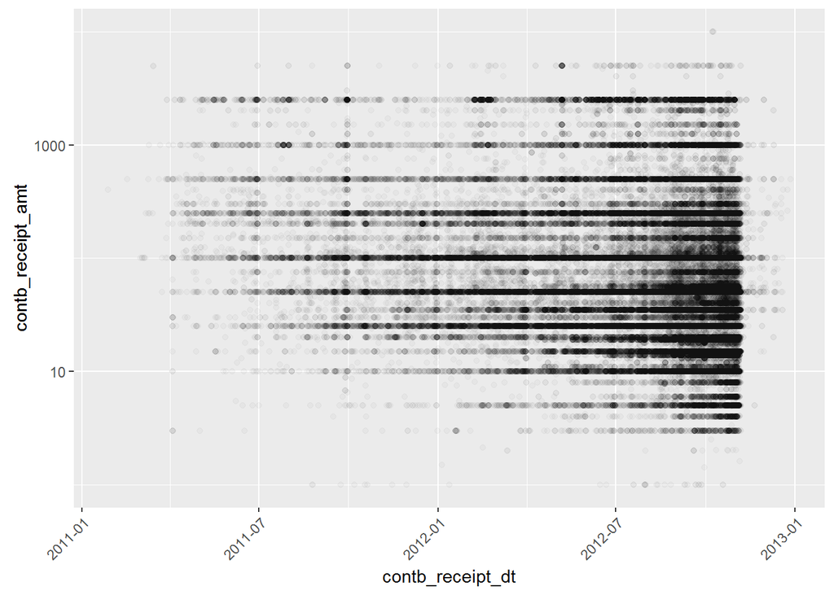

Not much of a trend in contribution amount and date. The amounts appear to stay constant across time. There does appear to be more data points toward the end of the election season. I want to try grouping the dates together to see if I can spot any kind of a trend in the amounts given in each month.

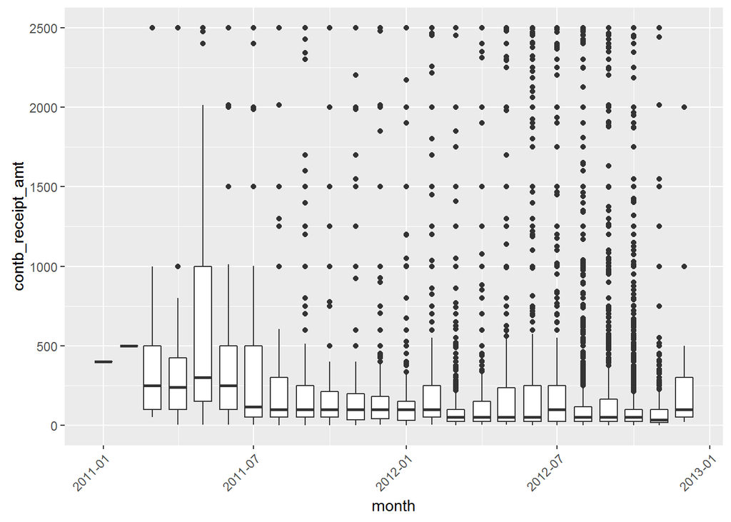

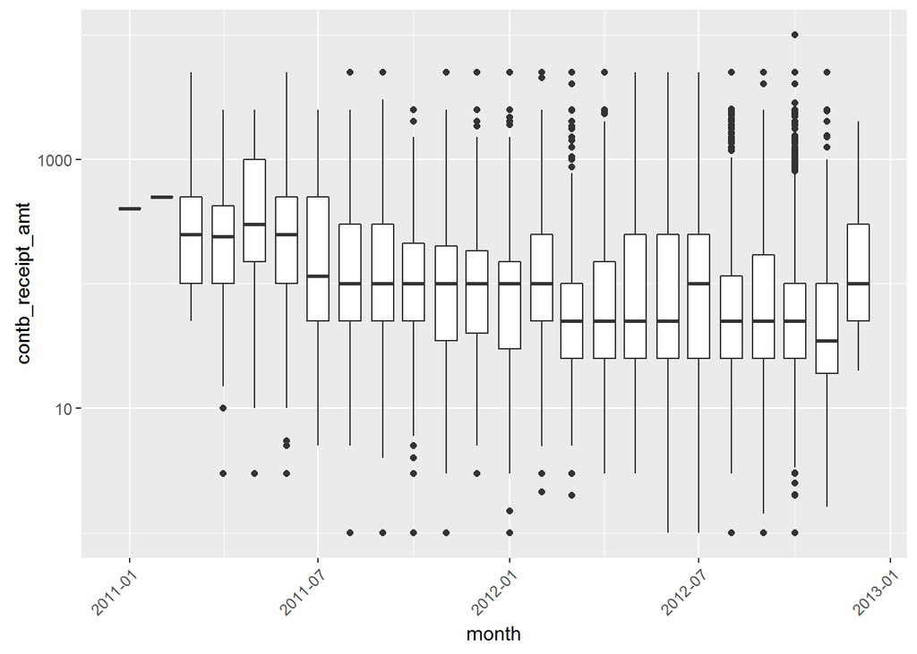

I want to show both the log transformed graph and not transformed graph here. In the former, you can begin to see a trend in when the contributions come to a campaign. It looks like the contributions ramp up a little bit after the first month of 2012, and around the conventions. In the latter, you can see a more broad trend of a higher number of outliers after the first of the year.

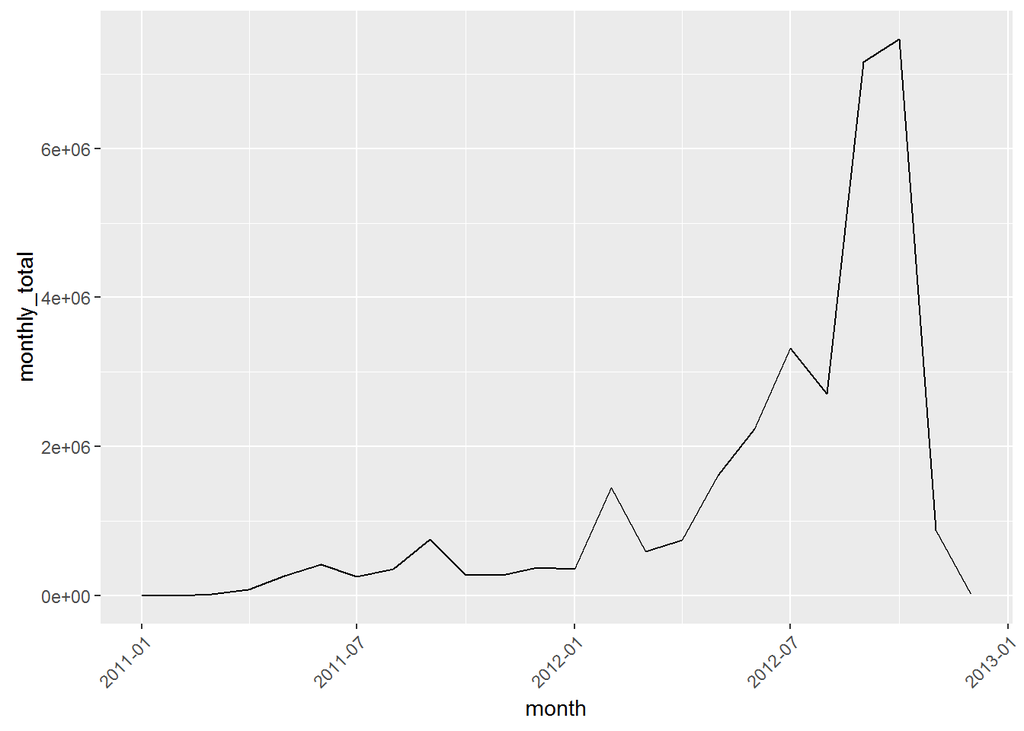

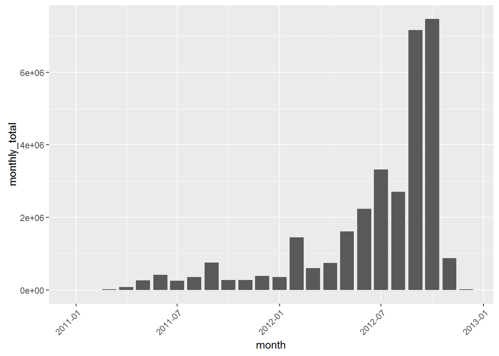

Contributions definitely ramp up toward the end of the election per the monthly totals. That makes a good bit of sense as there is a huge push to get donations toward the latter part of a campaign. Also voter interest tends to see a surge in the last few months of a campaign.

# Bivariate Analysis

### Did you observe any interesting relationships between the other features (not the main feature(s) of interest)?

I did not observe any interesting relationships between other features of the dataset. However, I did create a couple new variables to look at the relationship of contribution amount totals across time, month and week.

### What was the strongest relationship you found?

The strongest relationship I was able to find was between the total amount given in a month, and the month of the campaign. The monthly totals given seemed to ramp up as election day got closer.

# Multivariate Plots Section

```
##               cand_nm       month            monthly_total
##  Obama, Barack    :21   Min.   :2011-04-01   Min.   :     25
##  Romney, Mitt     :21   1st Qu.:2011-09-01   1st Qu.:  10209
##  Santorum, Rick   :19   Median :2012-01-16   Median :  63762
##  Paul, Ron        :17   Mean   :2012-01-16   Mean   : 391637
##  Bachmann, Michele: 0   3rd Qu.:2012-06-01   3rd Qu.: 213103
##  Cain, Herman     : 0   Max.   :2012-12-01   Max.   :5525245
##  (Other)          : 0
##   monthly_mean          n
##  Min.   :  25.0   Min.   :    1.0
##  1st Qu.: 108.9   1st Qu.:   40.5
##  Median : 178.7   Median :  229.0
##  Mean   : 323.0   Mean   : 1885.0
##  3rd Qu.: 396.7   3rd Qu.:  780.0
##  Max.   :1487.2   Max.   :27481.0
##
```

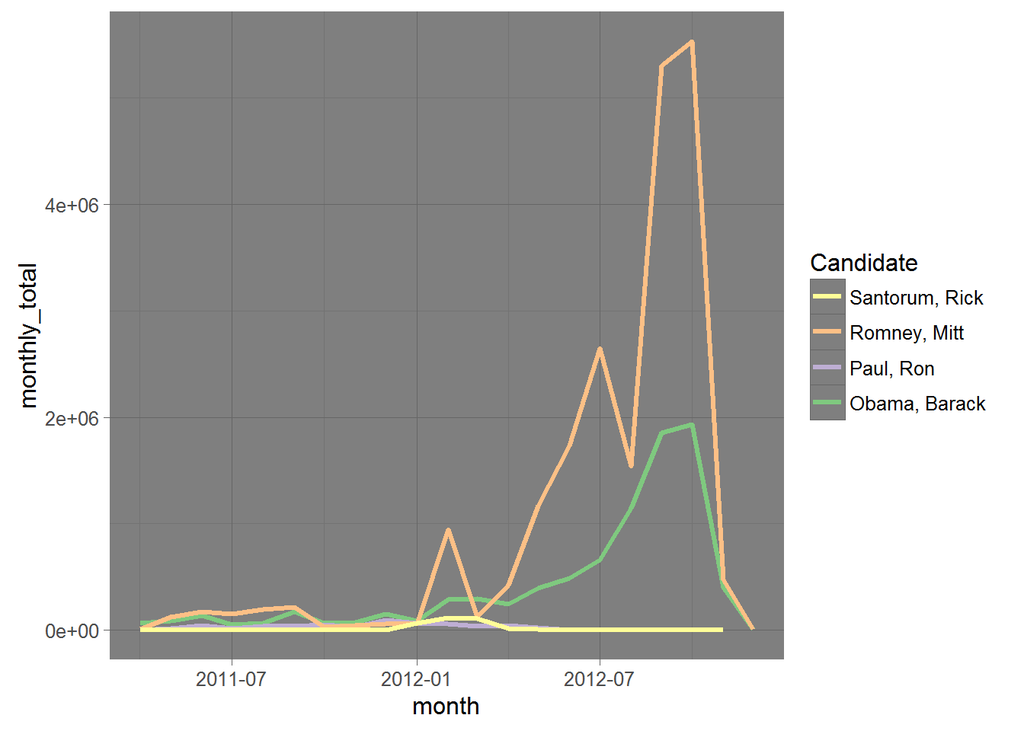

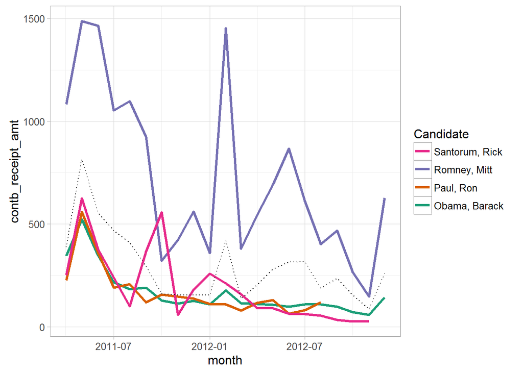

Monthly totals for Romney are higher in almost every month. The grand mean follows a mostly similar trend to the rest of the averages for the top 4 candidates.

```
##      contbr_city     month            monthly_total      monthly_mean
##  CINCINNATI:22   Min.   :2011-03-01   Min.   :     15   Min.   :  15.0
##  COLUMBUS  :22   1st Qu.:2011-08-16   1st Qu.:   7334   1st Qu.: 146.0
##  DAYTON    :22   Median :2012-02-01   Median :  16700   Median : 203.2
##  CLEVELAND :21   Mean   :2012-01-20   Mean   :  65527   Mean   : 300.9
##  DUBLIN    :21   3rd Qu.:2012-07-01   3rd Qu.:  47741   3rd Qu.: 356.7
##  AKRON     :20   Max.   :2012-12-01   Max.   :1017196   Max.   :1504.1
##  (Other)   :59
##        n
##  Min.   :   1.0
##  1st Qu.:  22.0
##  Median :  79.0
##  Mean   : 291.5
##  3rd Qu.: 218.0
##  Max.   :5753.0
##
```

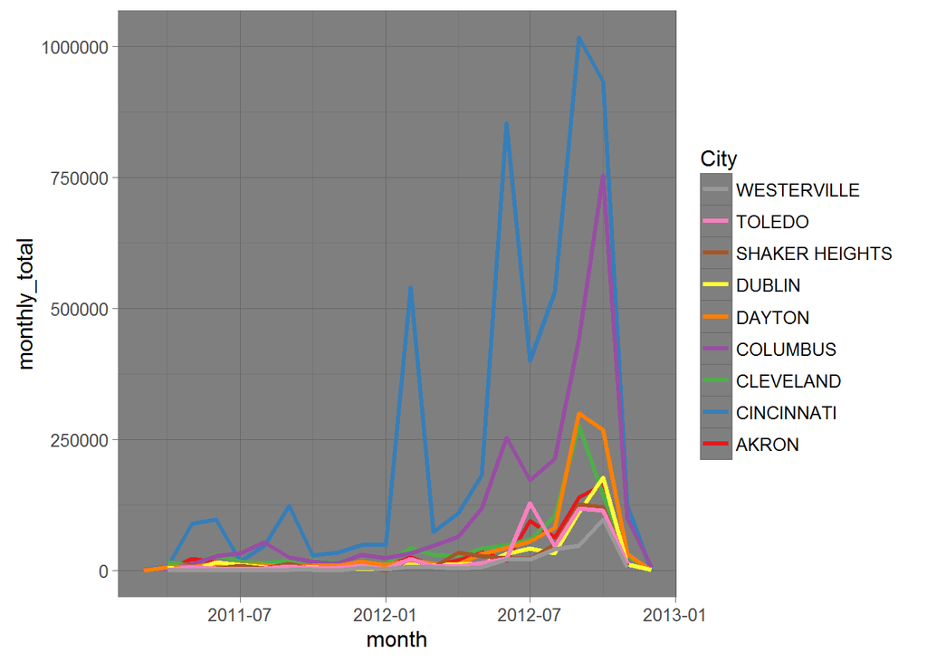

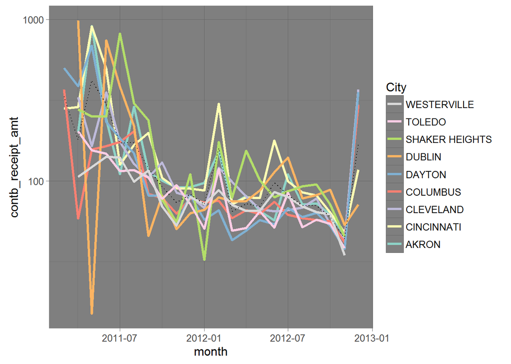

```
##              contbr_occupation     month            monthly_total
##  ATTORNEY             :22      Min.   :2011-03-01   Min.   :     70
##  INFORMATION REQUESTED:22      1st Qu.:2011-08-08   1st Qu.:   5656
##  PHYSICIAN            :22      Median :2012-02-01   Median :  18074
##  RETIRED              :22      Mean   :2012-01-22   Mean   :  76610
##  HOMEMAKER            :21      3rd Qu.:2012-07-01   3rd Qu.:  61890
##  PROFESSOR            :21      Max.   :2012-12-01   Max.   :1349849
##  (Other)              :60
##   monthly_mean           n
##  Min.   :  26.67   Min.   :    1.00
##  1st Qu.: 136.58   1st Qu.:   20.25
##  Median : 225.32   Median :   78.50
##  Mean   : 328.33   Mean   :  361.46
##  3rd Qu.: 405.49   3rd Qu.:  242.75
##  Max.   :1933.53   Max.   :11335.00
##
```

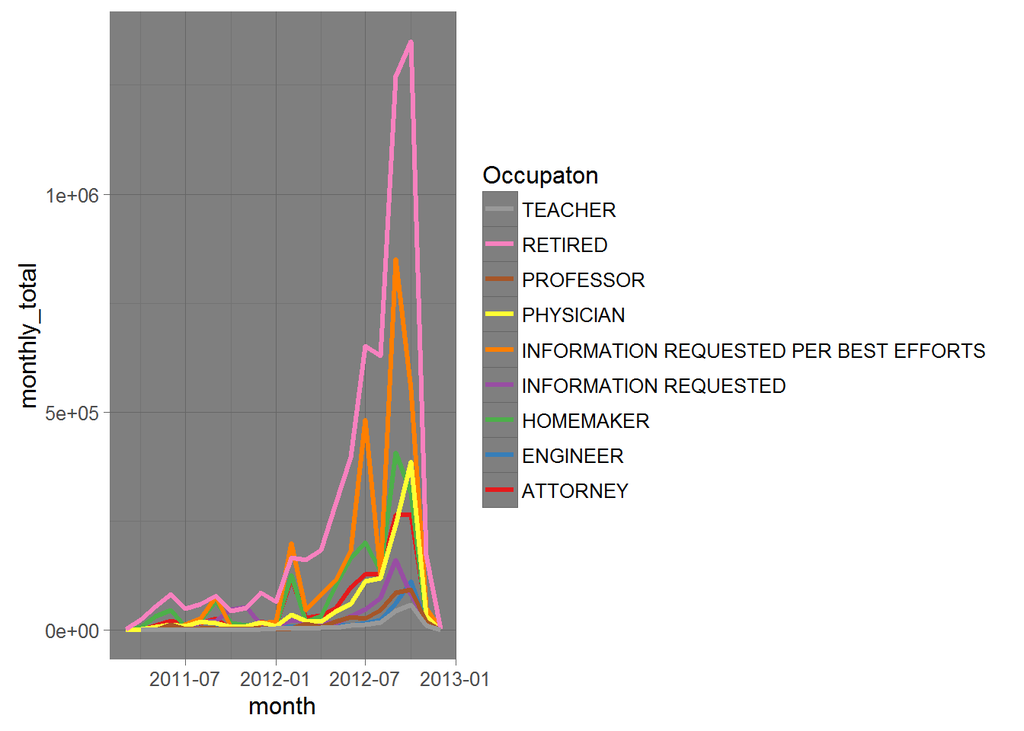

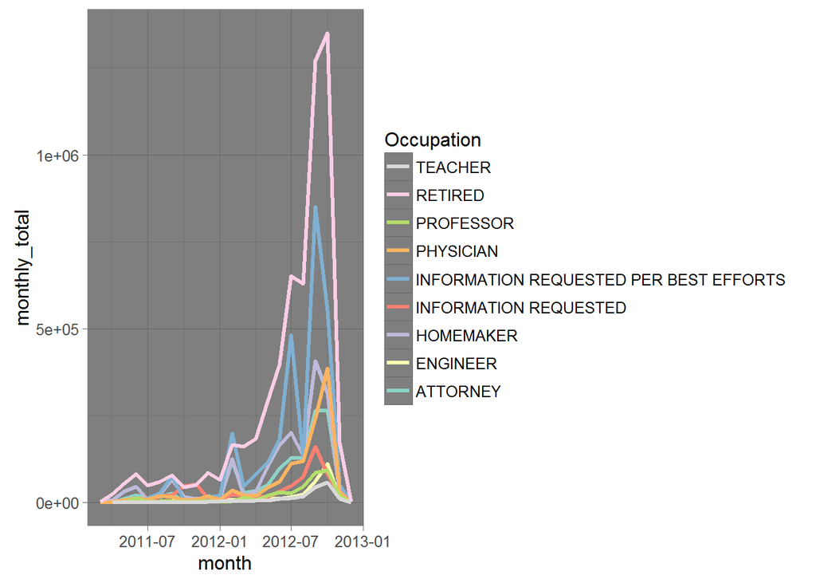

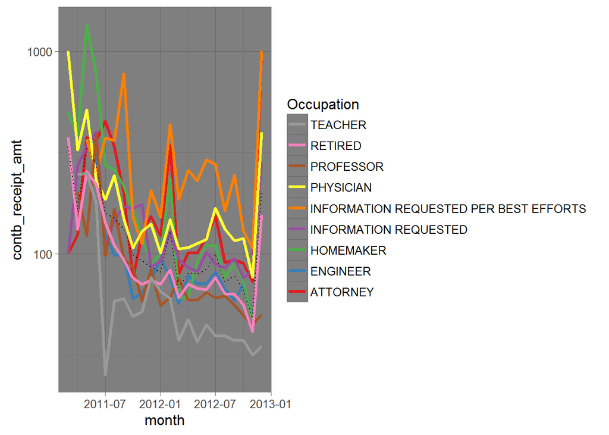

It shouldn’t be a huge surprise that Retired folks have a much higher monthly total in the later months of a campaign when engagement is the highest. They are the most represented group in the dataset so it makes pretty good sense that they would consisently have higher monthly contribution totals compared to other “professions.”

Before I wrap up the multivariate plots section, I want to see how the top occupations and the top cities gave to the top candidates. To do this, I’ll create a couple new dataframes using dplyr.

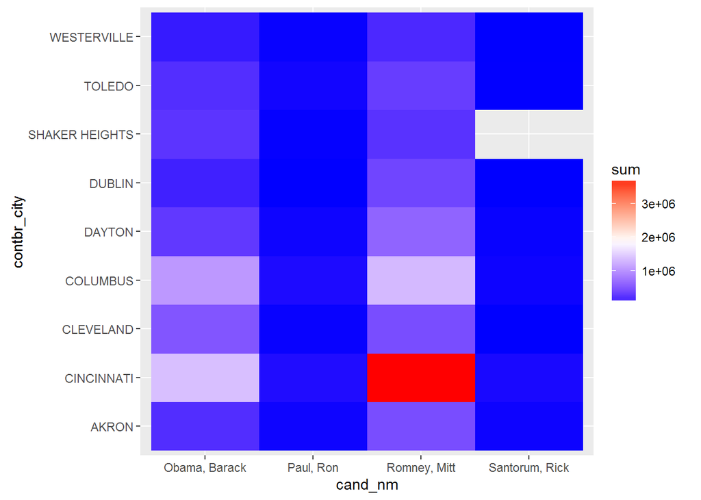

Rick Santorum did not receive any contributions in Shaker Heights. Mitt Romney raked in the dough in Cinncinati. Barack Obama got his contributions from a spread of cities.

Now lets see what the graph looks like for occupations.

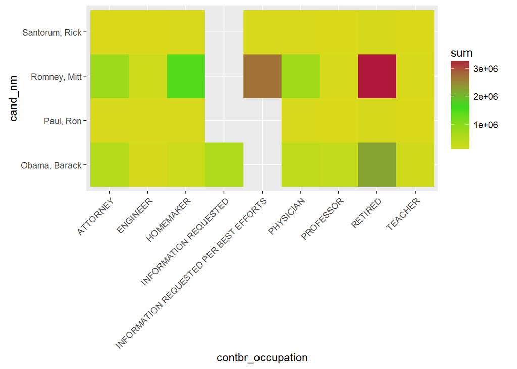

Mitt Romney cleaned up with retired folks and those for whom information on occupation could not be obtained. He also did well with homemakers. Barack Obama did well with retired folks as well, and had support across almost all the occupations.

# Multivariate Analysis

### Talk about some of the relationships you observed in this part of the investigation. Were there features that strengthened each other in terms of looking at your feature(s) of interest?

In looking at averages of contribution amounts by month for the candidates, the averages were higher earlier on in the campaign compared to later. This makes sense because those really engaged politically tend to be of a higher socio-economic status, who give their money to their preferred campaign earlier on, while the other end of the spectrum in terms of class comes around later on, and is of a lower socio-economic status.

Across month, city, and occupation, the monthly contribution totals increased as the campaign drew near. This makes sense because more people are tuning in. These totals are going up, despite the fact that average campaign contributions seem to decrease as the election gets closer. That’s an interesting, yet expected dicotmy.

### Were there any interesting or surprising interactions between features?

The most surprising or interesting interaction I saw was between the month, monthly_total, and candidate. Despite higher contribution totals for Romney in the state, he was soundly defeated by Obama in the election.

# Final Plots and Summary

### Plot One

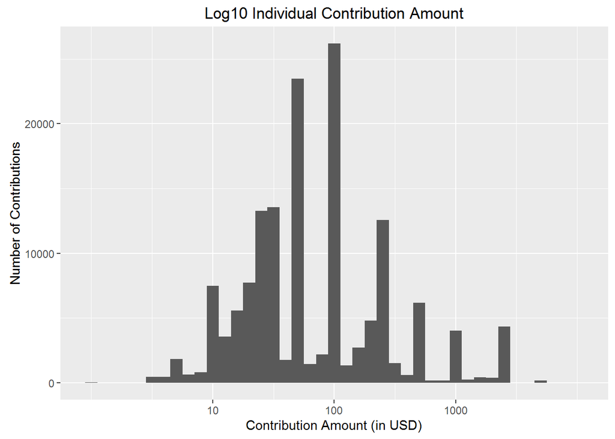

### Description One

The distribution of individual contributions on a log scale is fairly normalized. There looks to be slightly higher frequency on the lower side of $100, than on the higher side. Also, amounts 10, 50, 100, 500, and 1000, are pretty well represented.

### Plot Two

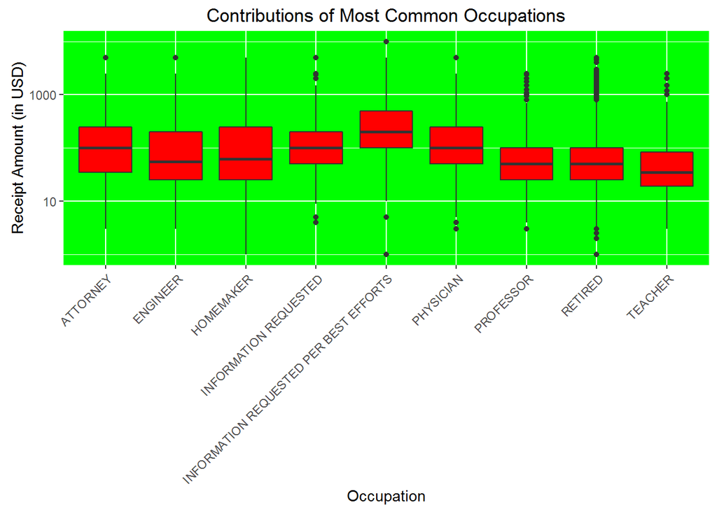

### Plot Three

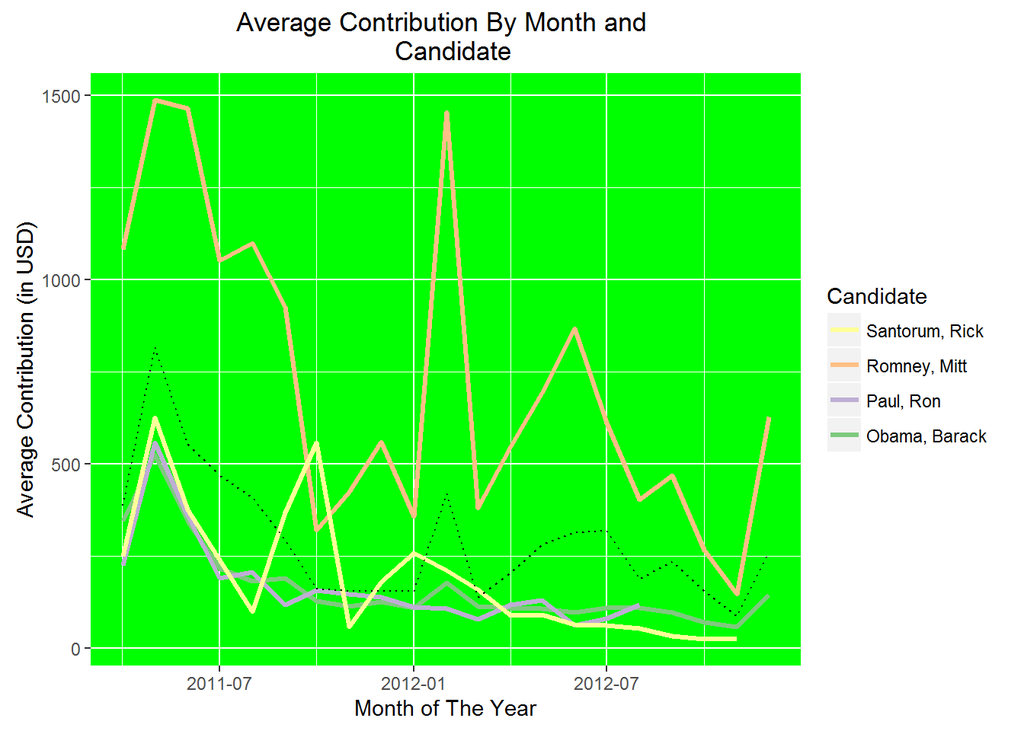

### Description Three

It’s somewhat surprising that the trend for the average contribution goes down as the election gets closer. From left to right, the averages begin to move downward, there is a spike at the beginning of the year, before they begin to decrease again after the time around the conventions. It sort of makes sense given those most likely to be engaged early on are wealthier and able to give more. Those who are less engaged tend to be less wealthy and more likely to engage with the race toward the latter weeks of a campaign, and there many more of those folks compared to the earlier crowd.

# Reflection

It was a pleasure to be able to work on this dataset. As I reflect on the project as a whole, the main difficulty stemmed from wondering how I was going to be able to present any findings of use or insights, which may not seem plausible on the surface. The data is somewhat limited because a good many of the variables are administrative in nature or for bookkeeping reasons, such as form_id. However, I was able to add a time series element to the data by adding new variables, month and Week, to the dataset. This led to some counterintuitive conclusions I myself wasn’t expecting. For example, in regard to Mitt Romney, fewer people in a higher concentration of cities, gave more fundraising dollars to him than Obama, who received his contributions from more people spread in concentration across more cities.

As for ideas or questions for future work, I think it would be worthwhile to do a deeper dive into the contributors/contributions for Mitt Romney and the contributors/contributions for Barack Obama. Even though Romney received more money and higher money totals, he was beaten in the state by Obama. This suggests that campaigns aren’t won by the amount of money a candidate receives, but rather the number of people who give to the candidate. Did Barack Obama have more contributors than Mitt Romney in the state of Ohio? If so, what were the demographics of those people? What does it suggest about the difference between the two campaigns?

I can’t say there were any really important decisions regarding the analysis of the dataset. However, early on, I did key in on the variables in the dataset I thought could illuminate the variable of interest, contribution amount, the best without doing a bunch of investigation on many of the variables I did not use, because they did not seem like they would add anything to the analysis. Also, I keyed in on the top occupations, cities, and candidates without doing much analysis of the middle or the bottom in each of those categories. The decision to do that was mainly due to thinking it would be harder to find any analysis or trend in a graph of any of those variables or attributes of the dataset.